**Цель работы:**  
Проанализировать сетевые параметры публичных DNS серверов, сделать мотивированный вывод о предпочтительных серверах.  
**Исходные данные:**

- `OS Kali Linux`
- `RStudio IDE`

**️Используемое ПО:**

- `tracert`
- `ping`
- `whois`

**Исследуемые провайдеры DNS:**

- `MTS PJSC`
- `Google Public DNS`
- `Cloudflare DNS`
- `OpenDNS`

**Ход работы:**

1. По исследуемым серверам собрать следующие данные:
   - маршрут;
   - местоположение каждого узла маршрута к DNS-серверу;
   - организацию, владеющую каждым узлом маршрута к DNS-серверу;
   - среднюю RTT к DNS-серверу.
2. Выделить те узлы маршрута, которые вносят наибольшую временную задержку при передаче;
3. Сравнить сетевые параметры DNS серверов.

**Данные DNS серверов:**

**[62.112.96.14] DNS MTS PJSC**

| № | ping #1 | ping #2 | ping #3 | Узел | Местоположение | Организация | AVG RTT |
| --- | --- | --- | --- | --- | --- | --- | --- |
| 1 | <1ms | 1ms | <1ms | 192.168.100.1 | Москва, Россия | Роутер | 1.4 |
| 2 | 3ms | 3ms | 3ms | 10.215.240.105 | Los Angeles, US | IANA | 3.6 |
| 3 | * | * | * | N/A | N/A | N/A |  |
| 4 | 4ms | 12ms | 4ms | 10.215.240.109 | Los Angeles, US | IANA | 6.8 |
| 5 | 4ms | 4ms | 4ms | 62.112.96.13 | Москва, Россия | MGTS adsl-rfc Client | 7 |
| 6 | 3ms | 3ms | 3ms | 62.112.96.14 | Москва, Россия | MGTS adsl-rfc Client | 4.6 |

**RTT=3ms**

**[8.8.8.8] Google Public DNS**

| № | ping #1 | ping #2 | ping #3 | Узел | Местоположение | Организация | AVG RTT |
| --- | --- | --- | --- | --- | --- | --- | --- |
| 1 | 1ms | <1ms | < 1ms | 192.168.100.1 | Москва, Россия | Роутер | 1.4 |
| 2 | 3ms | 3ms | 3ms | mpts-ss-51.msk.mts-internet.net[212.188.1.6] | Москва, Россия | MTS PJSC [former ZAO MTU-Intel] | 3.6 |
| 3 | 3ms | 3ms | 3ms | mag9-cr01-be12.51.msk.mts-internet.net[212.188.1.5] | Москва, Россия | MTS PJSC [former ZAO MTU-Intel] | 4.4 |
| 4 | 3ms | 4ms | 3ms | 72.14.223.74 | Mountain View, US | Google LLS | 5.7 |
| 5 | 4ms | 3ms | 4ms | 108.170.250.99 | Mountain View, US | Google LLS | 5.4 |
| 6 | 21ms | 22ms | 21ms | 172.253.66.116 | Mountain View, US | Google LLS | 21.4 |
| 7 | **29ms** | **42ms** | **19ms** | **172.253.66.108** | **Mountain View, US** | **Google LLS** | 30.5 |
| 8 | 21ms | 21ms | 20ms | 216.239.62.107 | Mountain View, US | Google LLS | 20.7 |
| 9 | * | * | * | N/A | N/A | N/A |  |
| 10 | * | * | * | N/A | N/A | N/A |  |
| 11 | * | * | * | N/A | N/A | N/A |  |
| 12 | * | * | * | N/A | N/A | N/A |  |
| 13 | * | * | * | N/A | N/A | N/A |  |
| 14 | * | * | * | N/A | N/A | N/A |  |
| 15 | * | * | * | N/A | N/A | N/A |  |
| 16 | * | * | * | N/A | N/A | N/A |  |
| 17 | * | * | * | N/A | N/A | N/A |  |
| 18 | 21ms | 21ms | 21ms | dns.google[8.8.8.8] | Mountain View, US | Google LLS | 20.2 |

**RTT=21ms**

**[1.1.1.1] Cloudflare DNS**

| № | ping #1 | ping #2 | ping #3 | Узел | Местоположение | Организация | AVG RTT |
| --- | --- | --- | --- | --- | --- | --- | --- |
| 1 | <1ms | <1ms | < 1ms | 192.168.100.1 | Москва, Россия | Роутер | 1.4 |
| 2 | 3ms | 4ms | 3ms | mpts-ss-51.msk.mts-internet.net[212.188.1.6] | Москва, Россия | MTS PJSC [former ZAO MTU-Intel] | 3.6 |
| 3 | 3ms | 3ms | 2ms | mag9-cr01-be12.51.msk.mts-internet.net[212.188.1.5] | Москва, Россия | MTS PJSC [former ZAO MTU-Intel] | 4.4 |
| 4 | 4ms | 3ms | 4ms | m9-cr04-be8.77.msk.mts-internet.net[212.188.54.213] | Москва, Россия | MTS PJSC [former ZAO MTU-Intel] | 5.4 |
| 5 | 5ms | 4ms | 3ms | m9-cr05-ae3.77.msk.mts-internet.net[195.34.53.185] | Москва, Россия | MTS PJSC [former ZAO MTU-Intel] | 5.4 |
| 6 | **25ms** | **22ms** | **31ms** | **172.68.8.254** | **San Francisco, US** | **Cloudflaire Inc.** | 25.5 |
| 7 | **27ms** | **24ms** | **21ms** | **one.one.one.one[1.1.1.1]** | **South Brisbane, Australia** | **Cloudflaire DNS** | 23.2 |

**[208.67.220.220] OpenDNS**

| № | ping #1 | ping #2 | ping #3 | Узел | Местоположение | Организация | AVG RTT |
| --- | --- | --- | --- | --- | --- | --- | --- |
| 1 | <1ms | <1ms | < 1ms | 192.168.100.1 | Москва, Россия | Роутер | 1.4 |
| 2 | 3ms | 3ms | 3ms | mpts-ss-51.msk.mts-internet.net[212.188.1.6] | Москва, Россия | MTS PJSC [former ZAO MTU-Intel] | 3.6 |
| 3 | 3ms | 3ms | 2ms | mag9-cr01-be12.51.msk.mts-internet.net[212.188.1.5] | Москва, Россия | MTS PJSC [former ZAO MTU-Intel] | 4.4 |
| 4 | 4ms | 4ms | 3ms | a197-cr04-be10.77.msk.mts-internet.net[195.34.50.73] | Москва, Россия | MTS PJSC [former ZAO MTU-Intel] | 5.2 |
| 5 | **109ms** | **110ms** | **109ms** | **che-cr02-ae1.63.sam.mts-internet.net[212.188.29.26]** | **Москва, Россия** | **MTS PJSC [former ZAO MTU-Intel]** | 25.4 |
| 6 | 36ms | 36ms | 36ms | psshag-cr01-ae10.63.chel.mts-internet.net[212.188.42.130] | Москва, Россия | MTS PJSC [former ZAO MTU-Intel] | 36.5 |
| 7 | 54ms | 54ms | 54ms | bhm-cr01-ae12.74.nsk.mts-internet.net[195.34.50.154] | Москва, Россия | MTS PJSC [former ZAO MTU-Intel] | 55 |
| 8 | **110ms** | **110ms** | **112ms** | **sem275-cr01-ae5.24.krsk.mts-internet.net[212.188.29.10]** | **Москва, Россия** | **MTS PJSC [former ZAO MTU-Intel]** | 65.6 |
| 9 | **109ms** | **110ms** | **109ms** | **akd-cr01-ae8.38.irk.mts-internet.net[212.188.29.138]** | **Москва, Россия** | **MTS PJSC [former ZAO MTU-Intel]** | 78.5 |
| 10 | **109ms** | **109ms** | **109ms** | **psskv-cr01-ae6.28.skv.mts-internet.net[212.188.28.213]** | **Москва, Россия** | **MTS PJSC [former ZAO MTU-Intel]** | 102.6 |
| 11 | **109ms** | **110ms** | **109ms** | **teat-cr01-ae0.28.blag.mts-internet.net[212.188.2.106]** | **Москва, Россия** | **MTS PJSC [former ZAO MTU-Intel]** | 111.6 |
| 12 | * | * | * | N/A | N/A | N/A |  |
| **13** | **243ms** | **243ms** | **243ms** | **resolver2.opendns.com[208.67.220.220]** | **San Francisco, US** | **Cisco OpenDNS, LLC** | 244.9 |

**RTT=242ms**

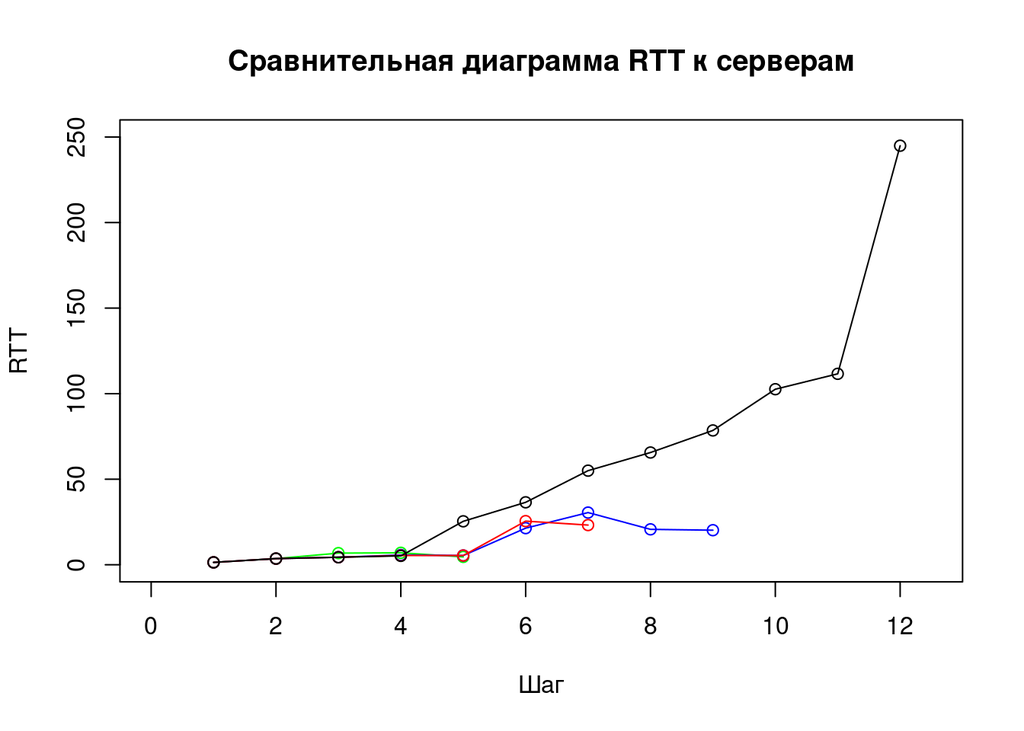

MTS PJSC  
Google Public DNS  
Cloudflare  
OpenDNS

**Оценка результата:**  
Больше всего времени затратилось при обращении к OpenDNS, меньше всего к MTS PJSC  
**Вывод:**  
RTT определяет задержку, с которой приходит ответ на запросы от удаленного сервера. Если приходится выбирать один из нескольких авторитативных серверов, выбор падает на сервер с наименьшим показателем RTT.